# Визуализация в ggplot2: кодим красивое

Антон Ангельгардт

7/07/2022

> `ggplot2` — мощный и популярный пакет для визуализации данных. Однако часто построение графиков ограничивается простыми шаблонами и выбором стандартных тем. Сегодня мы разберемся с тонкостями логики построения графика с помощью пакета `ggplot2`, научимся управлять отдельными элементами графика, а также узнаем, как подготовить визуализацию к публикации в соответствии с требованиями журнала, не используя сторонние программы.

# Что есть `ggplot2`?

`ggplot2` — это внешний пакет языка `R`, который позволяет строить красивые и сложные визуализации. Как и любой `R`-пакет, это набор функций, которые позволяют делать те или иные преобразования с графиками. Пакет `ggplot2` является частью семейства пакетов `tidyverse`.

```r
library(tidyverse)
```

# Сверхкраткое введение в `tidyverse`

## Что есть `tidyverse`

`tidyverse` — это пакет с пакетами для тех, кто занимается дата саенс. Пакеты хорошо стыкуются друг с другом и работают вместе в любви и гармонии, потому что

> they share common data representations and API design.

`tidyverse` per se, по факту, только обертка, чтобы было удобно скачать весь комплект пакетов. Мясо же распределено между ними.

## Что в пакетах?

- `ggplot2` — всё для визуализации, наш пакет интереса на сегодня
- `dplyr` — всякие приблуды для манипулирования с данными
- `tidyr` — штуки, чтобы привести данные к [tidy-виду](https://habr.com/ru/post/248741/)
- `readr` — для импорта данных
- `purrr` — для преисполнившихся в функциональном программировании
- `tibble` — всё, что связано с tibbles [это как датафреймы, только моднее]
- `stringr` — всякое для работы со строками
- `forcats` — разное для работы с факторами

## Что особенного?

**Синтаксис.**

### Велосипедик

`tidyverse` настолько крут, что его него есть свой синтаксис, основная особенность которого — это пайп (pipe): `%>%`. Вводится через **Ctrl + Shift + M** (**⌘ + Shift + M**). Этот «велосипедик» работает по очень простой схеме: передаёт то, что слева, первым аргументом функции, которая справа. Вот пример:

```r
round(pi, 2)
```

```
## [1] 3.14
```

```r
pi %>% round(2)
```

```
## [1] 3.14
```

С помощью этого оператора можно выстраивать конвейеры из функций, следующих друг за другом:

```r
pi %>%
  sqrt() %>%
  round(3) %>%
  sin() %>%
  `/`(1, .) %>%
  exp() %>%
  round(2)
```

```
## [1] 2.77
```

Это существенно повышает redability кода.

# Зачем вообще рисовать?

Рассмотрим два примера.

## Квартет Анскомба

Грузим датасет:

```r
quartet <- read_csv("https://raw.githubusercontent.com/angelgardt/hseuxlab-wlm2021/master/data/anscombe.csv")
```

Считаем описательные статистики:

```
## # A tibble: 4 x 7
##   dataset mean.x  sd.x mean.y  sd.y   cor n_obs
##     <dbl>  <dbl> <dbl>  <dbl> <dbl> <dbl> <dbl>
## 1       1      9  3.32    7.5  2.03  0.82    11
## 2       2      9  3.32    7.5  2.03  0.82    11
## 3       3      9  3.32    7.5  2.03  0.82    11
## 4       4      9  3.32    7.5  2.03  0.82    11
```

Одинаковое.

Рисуем:

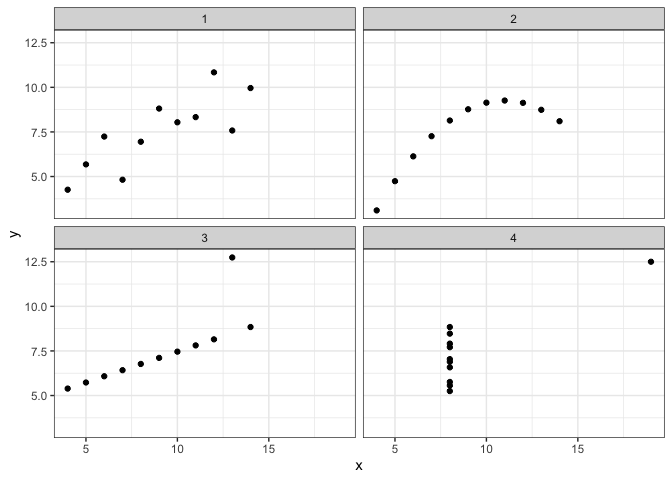

Разное…

## Datasaurus

Грузим датасет:

```r
datasaurus <- read_csv("https://raw.githubusercontent.com/angelgardt/hseuxlab-wlm2021/master/data/datasaurus.csv")
```

Считаем описательные статистики:

```
## # A tibble: 13 x 7
##    dataset    mean.x  sd.x mean.y  sd.y   cor n_obs
##    <chr>       <dbl> <dbl>  <dbl> <dbl> <dbl> <dbl>
##  1 away         54.3  16.8   47.8  26.9  -0.1   142
##  2 bullseye     54.3  16.8   47.8  26.9  -0.1   142
##  3 circle       54.3  16.8   47.8  26.9  -0.1   142
##  4 dino         54.3  16.8   47.8  26.9  -0.1   142
##  5 dots         54.3  16.8   47.8  26.9  -0.1   142
##  6 h_lines      54.3  16.8   47.8  26.9  -0.1   142
##  7 high_lines   54.3  16.8   47.8  26.9  -0.1   142
##  8 slant_down   54.3  16.8   47.8  26.9  -0.1   142
##  9 slant_up     54.3  16.8   47.8  26.9  -0.1   142
## 10 star         54.3  16.8   47.8  26.9  -0.1   142
## 11 v_lines      54.3  16.8   47.8  26.9  -0.1   142
## 12 wide_lines   54.3  16.8   47.8  26.9  -0.1   142
## 13 x_shape      54.3  16.8   47.8  26.9  -0.1   142
```

Одинаковое…

Рисуем:

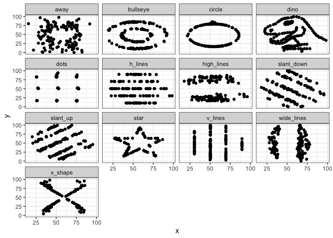

Ух ты ж ёш ты ж — ничоси!

**Вывод:** цифры — это хорошо, нужно и полезно, но недостаточно, так как они не отражают *паттернов* и всех *закономерностей*, которые нам могут быть важны для исследований. Следовательно, нельзя пренебрегать визуализациями — как разведочными, так и результатов.

# Философия A Layered Grammar of Graphics

Идея, воплощенная в `ggplot2`, восходит к работе [L. Wilkinson «The Grammar of Graphics»](https://www.springer.com/gp/book/9780387245447). Базируясь на идеях, изложенных в этой работе, Hadley Wickham разработал концепцию [Layered Grammar of Graphics](https://doi.org/10.1198/jcgs.2009.07098) и создал мощный пакет для визуализации, ради которого мы все здесь собрались. Автором по этому пакету написана целая [книга](https://www.springer.com/gp/book/9780387981413), но мы сосредоточимся на основных смысловых и ключевых моментах, которые необходимы, чтобы сделать что-то крутое.

> Часто возникает вопрос: почему 2? Ответ примерно такой: был и первый `ggplot`, но попытка не задалась от слова совсем, и пришлось все переделать.

## Собственно к философии построения графиков

По своей сути график представляет собой сложную аппликацию из нескольких слоев. На каждом слое располагаются сходные по содержанию элементы. Начиная с самого первого — базового — и постепенно добавляя слой за слоем необходимые элементы, можно создавать сложные визуализации для отображения интересных закономерностей в данных.

После создания базового графика осуществляется настройка отдельных элементов по необходимости и в зависимости от требований издательства / преподавателя / научника / комиссии и т.д. И поскольку все элементы в определенной степени изолированы друг от друга, это открывает большие возможности кастомизации. Кроме того, чтобы оформить график в соответствии с конкретными требованиями, нет необходимости перерисовывать его целиком, так как содержательная часть графика независима от настроек внешнего облика. Все, что вам нужно — это добавить/удалить пару строк кода.

Но — хватит слов! Поехали уже рисовать уже!

## Данные

Грузим! Датасет номер раз:

```r
dirtDoz <- read_csv("https://raw.githubusercontent.com/angelgardt/angelgardt.github.io/master/appcogsci2022/dirtyDozen.csv")
```

Датасет номер два:

```r
share <- read_delim("https://raw.githubusercontent.com/angelgardt/angelgardt.github.io/master/appcogsci2022/share.csv",
                    delim = " ", locale = locale(decimal_mark = ","))
```

Датасет номер три:

```r
ajt <- read_csv("https://raw.githubusercontent.com/angelgardt/angelgardt.github.io/master/appcogsci2022/ajt_data.csv")
```

Сегодня у нас есть трое данных. Первые — поведенческие. Это `share`. Это данные эксперимента, в котором пользователи Android и iOS искали иконки «share» обеих платформ среди универсальных иконок. Короче, зрительный поиск.

Переменные в датасете следующие:

- `trialtype` — тип пробы (`tray`/`dots`/`both`)
- `setsize` — количество стимулов в пробе (`8`/`12`/`16`)
- `time1` — время первого клика
- `time2` — время второго клика
- `id` — индентификатор испытуемого
- `platform` — платформа смартфона (`Android`/`iOS`)
- `correct1` — был ли корректным первый клик (найден ли первый целевой стимул)
- `correct2` — был ли корректным второй клик (найден ли второй целевой стимул)

Вторые — опросниковые. Это `dirtDoz`. Это данные прохождения опросника «Темная дюжина» старшеклассниками российских школ.

Переменные таковы:

- `age` — возраст респондента
- `gender` — гендерная принадлежность респондента (`male`/`female`/`other`)
- `class` — класс, в котором обучается респондент
- `mac` — балл по шкале макиавеллизма
- `nar` — балл по шкале нарциссизма
- `psy` — балл по шкале психопатии

Третьи — лингвистические. Это `ajt`. Это данные исследования усвоения русского языка как второго. Информанты решали задачу AJT (acceptability judgement task), в которой необходимо было сказать, насколько представленное предложение приемлемо для русского языка. Задачу решали нейтивы и элтушники.

Переменные вот:

- `id` — ID информанта
- `time` — время, затраченное на выполнение всего задания (оценку приемлемости всех предложений)
- `group` — группа информантов (русский язык родной — `L1` / русский язык иностранный — `L2`)
- `number` — номер предложения
- `item` — текст предложения
- `value` — ответ информанта

Ну, вот с данными мы познакомились — теперь можно расчехлять кисти!

# Базовая визуализация

## Базовый слой

Когда мы собираемся рисовать, мы берем холст. Когда мы начинаем рисовать график в `ggplot2`, первое, что нам надо ему сказать — «Дай мне холст!». На языке `ggplot2` это делается с помощью команды `ggplot()`:

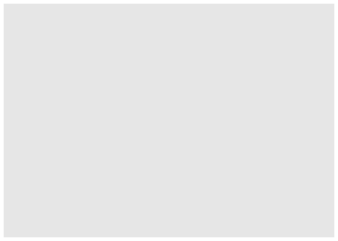

```r
ggplot()
```

Получите — распишитесь. `ggplot2` дал нам холст. Иначе говоря, мы построили *базовый слой*, на котором далее будем располагать элементы нашего графика.

Следующее, что нам нужно сделать, это указать данные, по которым мы будем строить нашу визуализацию. Это делается с помошью аргумента `data`:

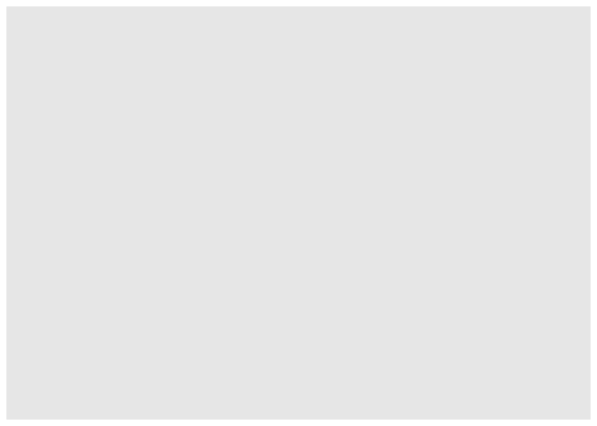

```r
ggplot(data = dirtDoz)
```

Вроде бы ничего не изменилось, да и собственно, не должно было, ведь мы никак не указали, что мы хотим отобразить. Давайте укажем.

## Разметка осей

Важнейшие элементы любого графика — это оси. Мы строим двумерные графики, поэтому и оси у нас две — как учили в школе, `x` (горизонтальная ось, ось абсцисс) и `y` (вертикальная ось, ось ординат).

Чтобы задать оси графика потребуется отдельная функция. Она называется `aes()`, и в общем задает *эстетики графика*.

### Эстетики (aesthetics)

Итак, конкретнее об эстетиках. Иначе говоря, это то форматирование, которое связано с данными. Или еще один способ понимания: эстетики — это способы отображения переменных из датасета. У функции `aes()` есть ряд параметров, они тоже называются эстетики.

Вот список эстетик, которые используются чаще всего: `x`, `y`, `color`, `fill`, `shape`, `size`.

Несложно догадаться, что переменные по осям задаются параметрами `x` и `y`. Что ж, зададим.

Давайте визуализируем связь между нарциссизмом и макиавеллизмом (вернее, между баллами по этим шкалам):

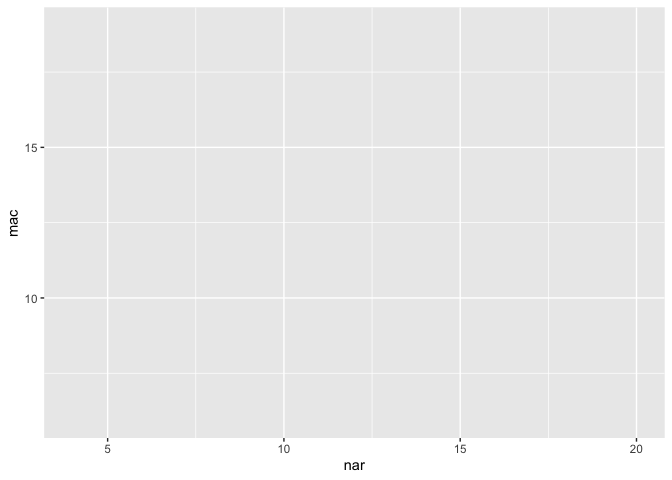

```r
ggplot(data = dirtDoz,
       aes(nar, mac))
```

Так, ну, допустим… А где картинка?

Картинки нет, но `ggplot2` честно отработал свою работу. Мы задали только оси — и он нам разметил их в соответствии с имеющимися в векторах значениях. Больше мы ему ничего не написали. Чтобы всё-таки получить картинку, необходимо указать, как мы хотим отборазим наши переменные.

## Геомы

За то, каким образом будут отображены переменными, а конкретно, какими «геометрическими объектами», отвечает семейство функций `geom_*`. Когда мы переходим к этой функции, мы переходим на новый слой. Чтобы это обозначить используется плюсик `+`:

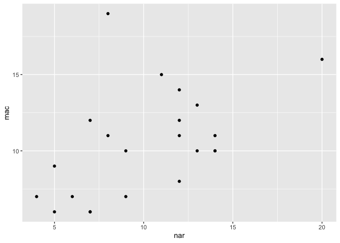

```r
ggplot(data = dirtDoz,
       aes(nar, mac)) +
  geom_point()
```

Мы выбрали точки для отображения переменных, потому что это наиболее наглядный вариант отобразить зависимость между двумя переменными. Такой тип графика называется *scatterplot*, или *диаграмма рассеяния*.

Но, вообще-то, можно и получше отобразить закономерность. Как минимум, добавить *линию тренда* с помощью специального геома:

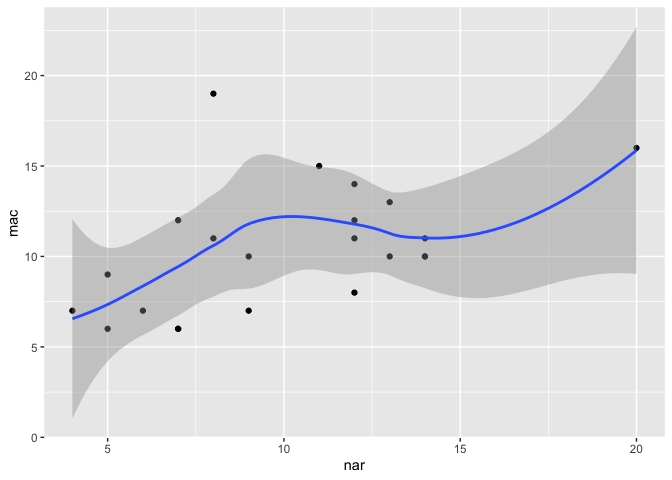

```r
ggplot(data = dirtDoz,
       aes(nar, mac)) +
  geom_point() +
  geom_smooth()
```

Как видите, при добавлении нового «геометрического» способа отображения данных мы добавляем новый слой.

Сейчас мы гораздо отчетливее видим, что есть некоторый тренд — с ростом баллов по одной из шкал растут баллы и по другой. Но мы можем визуализировать закономерность ещё более явно. Так как `geom_smooth()` подразумевает «сглаживание», оно может происходить с помощью разных методов (используемый метод нам написали в консоль). Мы можем эскплицинто указать, какой метод хотим использовать. Например, линейную регрессию:

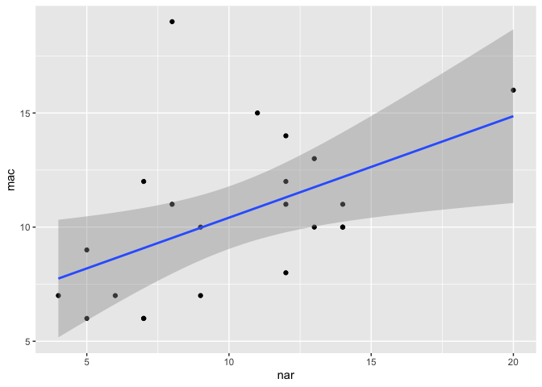

```r
ggplot(data = dirtDoz,
       aes(nar, mac)) +
  geom_point() +
  geom_smooth(method = "lm")
```

Вот вам, пожалуйста, красивый линейный тренд.

## Больше информации на график

Как мы помним из структуры данных (и теории), в Тёмную Триаду входят три [^1] черты. Мы пока отобразили зависимость между двумя. Хотелось бы добавить третью и при этом не выйти в 3D — всё-таки мы собираемся это печатать в статье.

### Цвет

Цвет — удивительная шкала. Она может быть дискретной и непрерывной, порядковой и категориальной. То есть, мы можем сделать вот так:

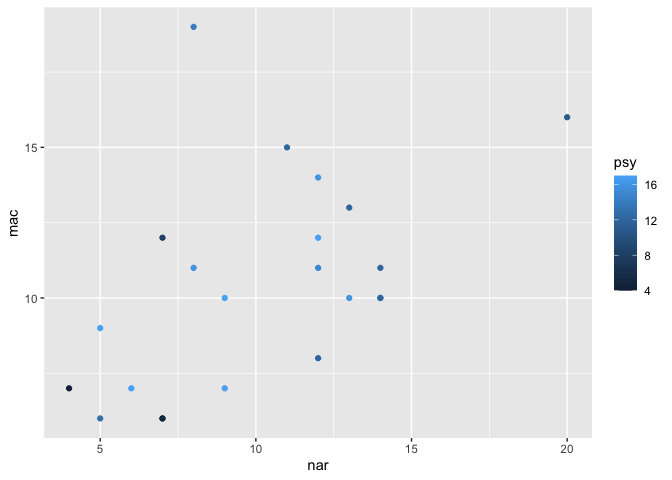

```r
ggplot(data = dirtDoz,
       aes(nar, mac, color = psy)) +
  geom_point()
```

Мы задачи отображение количественной переменной с помошью цвета и эффектно отобразили связь между тремя количественными переменными на двумерном графике. Ну и кто тебе скажет, что мы не боги визуализации?

## Фасетирование

Мы уже отобразили приличное количество информации, но недостаточное. Давайте ещё нашу выборку по гендеру разобьем — будет весело! Чтобы на одном субграфике были мальчики, а на другом девочки. Для этого есть семейство функций `facet_*()`:

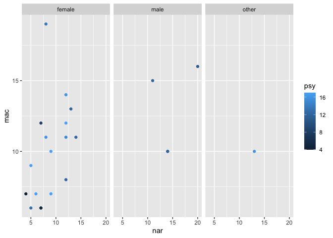

```r
ggplot(data = dirtDoz,
       aes(nar, mac, color = psy)) +
  geom_point() +
  facet_wrap(~ gender)
```

Я обещал, что будет весело. Давайте исключим из анализа единственную небинарную персону — заодно посмотрим, как филигранно tidyverse сплетается с `ggplot2`:

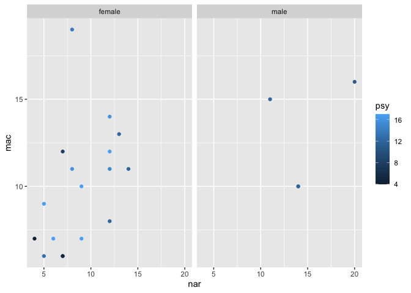

```r
dirtDoz %>%
  filter(gender != "other") %>%
  ggplot(aes(nar, mac, color = psy)) +
  geom_point() +
  facet_wrap(~ gender)
```

Ну, что-то такое. Вот теперь это окончательный вариант базовой визуализации. Ура!

# Настройка графика

Но рано радоваться — время кодить, солнце ещё не взошло!

Содержание на график мы вывели, однако в таком виде публиковать его категорически нельзя. Необходимо поработать над деталями.

## Эстетики, но под другим углом

Оцените размер точек — кажется маловаты, да? Надо нарисовать их побольше. Для этого есть параметр size:

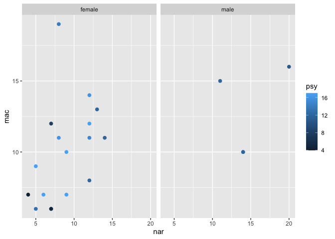

```r
dirtDoz %>%
  filter(gender != "other") %>%
  ggplot(aes(nar, mac, color = psy)) +
  geom_point(size = 2) +
  facet_wrap(~ gender)
```

Вот, так стало значительно приятнее и проще смотреть. Обратите внимание, что в этом случае мы задавали значение аргумента `size` вне функции `aes()`, так как он не связан с самими данными — значение `2` мы берем извне, задаем произвольно.

## Подписи осей

Поддерживаете вы отечественного производителя или стремитесь опубликоваться в журнале «Природа» — переменные на графике должны быть подписаны нормально [^2]. То есть из подписи оси (эстетики) должно быть понятно, какой показатель отображён на графике. Что ж, подпишем.

Для этого есть функция `labs()`, которая позволяет подписать [почти] всё и сразу. И это будет новый слой:

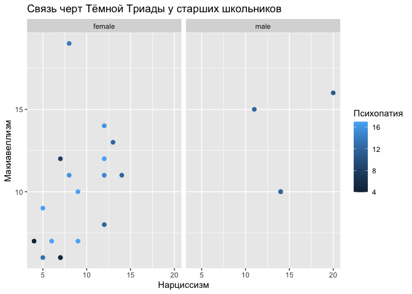

```r
dirtDoz %>%
  filter(gender != "other") %>%
  ggplot(aes(nar, mac, color = psy)) +
  geom_point(size = 2) +
  facet_wrap(~ gender) +
  labs(x = "Нарциссизм",
       y = "Макиавеллизм",
       color = "Психопатия",
       title = "Связь черт Тёмной Триады у старших школьников")
```

Ну, уже как будто прилично.

## Тема

Но серый дефолтный фон до добра ещё никого не доводил. Когда-то стандартная тема `ggplot2` была очень популярна, так как позволяла заявить, что ты «могёшь в R» и «как мощны твои количественные методы», но нынче публика уже значительно искушенная в этом вопросе. Да и на самом деле, серый фон снижает контрастность, в результате чего восприятие визуализации затрудняется. Проведем этот день под лозунгом: «Даёшь контрастность каждой визуализации!»

Нам всего лишь надо сменить тему. Я люблю чёрно-белую, другие предпочитают минималистичную. Выбор за вами, но я сделаю вот так:

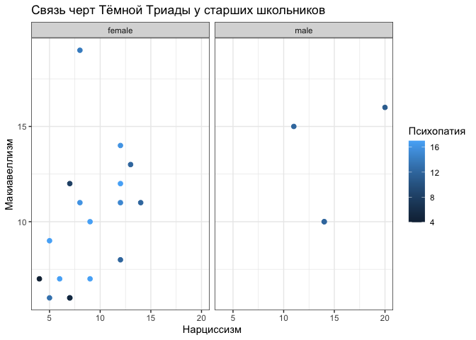

```r
dirtDoz %>%
  filter(gender != "other") %>%
  ggplot(aes(nar, mac, color = psy)) +
  geom_point(size = 2) +
  facet_wrap(~ gender) +
  labs(x = "Нарциссизм",
       y = "Макиавеллизм",
       color = "Психопатия",
       title = "Связь черт Тёмной Триады у старших школьников") +
  theme_bw()
```

Красuво!

## Подписи фасетов

О нет! Мы же забыли исправить названия субграфиков — они там всё ещё на латинице висят. Секундочку, щас всё будет!

Для этого нам надо завести именованный вектор: имена — это исходные названия уровней категориальной переменной, а сами элементы вектора — это лейблы, которые должны отображаться на графике. В нашем случае вот так:

```r
la <- c(male = "Мальчики",
        female = "Девочки")
```

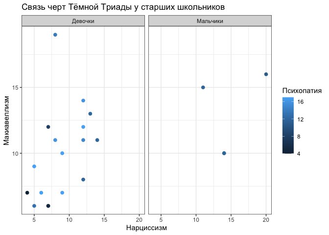

```r
dirtDoz %>%
  filter(gender != "other") %>%
  ggplot(aes(nar, mac, color = psy)) +
  geom_point(size = 2) +
  facet_wrap(~ gender,
             labeller = labeller(gender = la)) +
  labs(x = "Нарциссизм",
       y = "Макиавеллизм",
       color = "Психопатия",
       title = "Связь черт Тёмной Триады у старших школьников") +
  theme_bw()
```

Фух, слава Богу… Поправили.

## Оптимизация

Кажется, что легеда, располагающаяся справа — это невыгодно. Почему? Нам мы хотелось показать взаимоотношения между переменными, растянув точки порише. Мы могли бы переместить легенду вниз, освободив пространство справа. Давайте так и сделаем. Для этого нам надо подправить некоторые элементы темы:

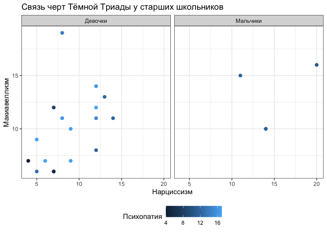

```r
dirtDoz %>%
  filter(gender != "other") %>%
  ggplot(aes(nar, mac, color = psy)) +
  geom_point(size = 2) +
  facet_wrap(~ gender,
             labeller = labeller(gender = la)) +
  labs(x = "Нарциссизм",
       y = "Макиавеллизм",
       color = "Психопатия",
       title = "Связь черт Тёмной Триады у старших школьников") +
  theme_bw() +
  theme(legend.position = "bottom")
```

Теперь и общая композиция симметричнее стала. Но вот маленькая напасть: подпись «Психопатия» теперь как будто проситься, чтобы её подтянули повыше — выровняли по центру с цветовой шкалой. Штош, это потребует чуть большего количества пальцедвижений, но её прошение мы удовлетворим.

> Под капотом `ggplot2` развернута сложная система ООП, в которую мы вникать не будем, иначе нам никакого кофе не хватит. Но сейчас мы подойдём к ней максимально близко.

Подпись «Психопатия» — это, во-первых, текстовый элемент, а во-вторых, заголовок легенды. Теперь внимательно следите за руками и названиями аргументов и функций:

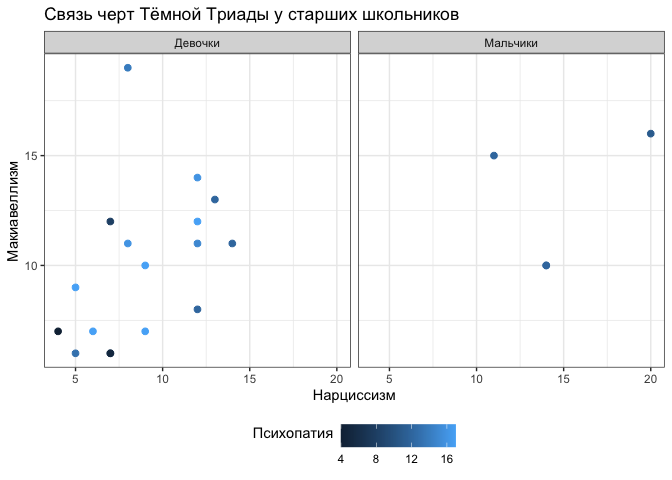

```r
dirtDoz %>%
  filter(gender != "other") %>%
  ggplot(aes(nar, mac, color = psy)) +
  geom_point(size = 2) +
  facet_wrap(~ gender,
             labeller = labeller(gender = la)) +
  labs(x = "Нарциссизм",
       y = "Макиавеллизм",
       color = "Психопатия",
       title = "Связь черт Тёмной Триады у старших школьников") +
  theme_bw() +
  theme(legend.position = "bottom",
        legend.title = element_text(vjust = .9))
```

Мы взяли аргумент `legend.title`, который управляет заголовком легенды, а так как заголовок — это текстовый элемент, то аргумент ждёт результата работы функции `element_text()`. Из все возможных опций управления текстом нас сейччас интересует выравнивание по вертикали (vertical justification) (`vjust`). Число подбираем визуально.

Это было непросто, но мы справились. Давайте ещё заголовок графика до кучи по центру поставим — и отправляем в журнал:

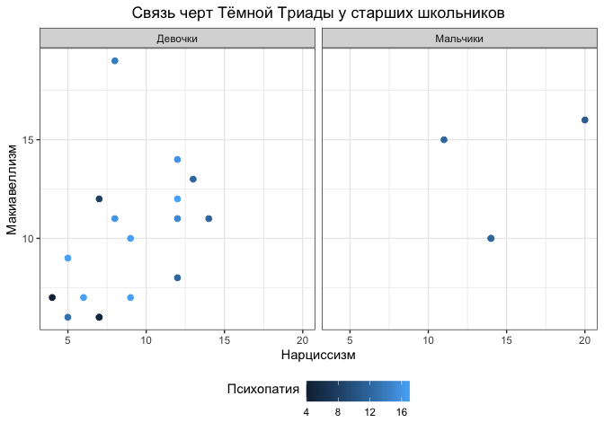

```r
dirtDoz %>%
  filter(gender != "other") %>%
  ggplot(aes(nar, mac, color = psy)) +
  geom_point(size = 2) +
  facet_wrap(~ gender,
             labeller = labeller(gender = la)) +
  labs(x = "Нарциссизм",
       y = "Макиавеллизм",
       color = "Психопатия",
       title = "Связь черт Тёмной Триады у старших школьников") +
  theme_bw() +
  theme(legend.position = "bottom",
        legend.title = element_text(vjust = .9),
        plot.title = element_text(hjust = .5))
```

# Необычные фишечки [1]

Иногда с фасетами возникает проблема.

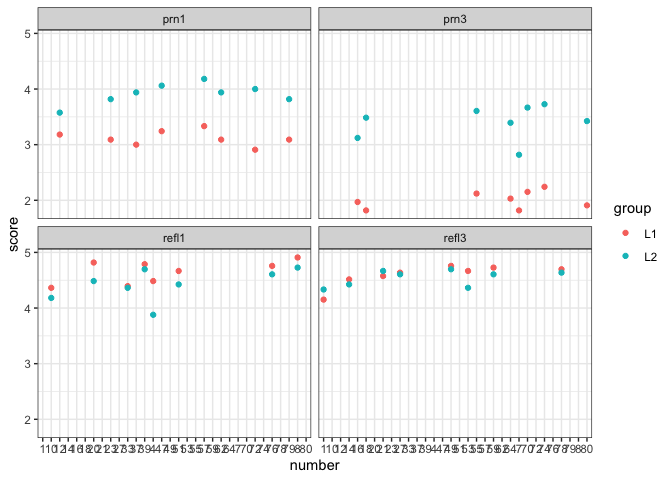

```r
ajt %>%
  filter(cond != "ungram") %>% # убираем неграмматичное условие
  mutate(number = as.character(number)) %>% # подправляет тип переменной
  group_by(number, group, cond) %>% # группируем по условиям
  summarise(score = mean(value)) %>% # усредняем ответы информантов
  ggplot(aes(number, score, color = group)) +
  geom_point() +
  facet_wrap(~ cond) +
  theme_bw()
```

Так как у нас часть предложений была в одном условии, часть в другом, часть в третьем и т.д., на графике мы видим «дырки» — естественно, те предложения, которых не было в конкретном условии, не отображены на субграфике этого условия. При этом шкала у субграфиков по умолчанию общая. Хоцца сделать так, чтобы было не общая.

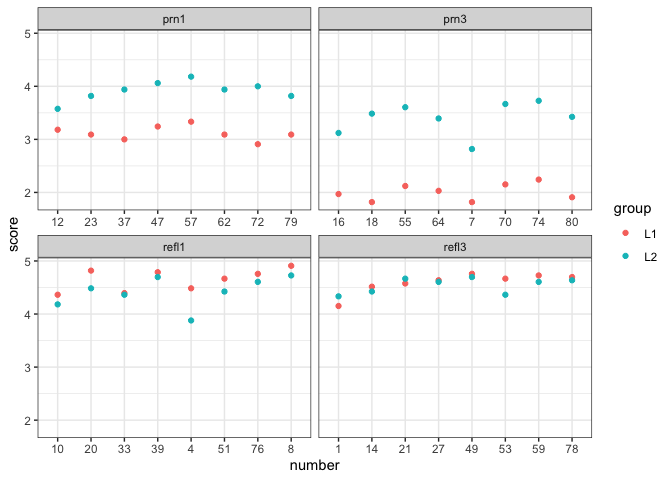

```r
ajt %>%
  filter(cond != "ungram") %>%  # убираем неграмматичное условие
  mutate(number = as.character(number)) %>% # подправляет тип переменной
  group_by(number, group, cond) %>% # группируем по условиям
  summarise(score = mean(value)) %>% # усредняем ответы информантов
  ggplot(aes(number, score, color = group)) +
  geom_point() +
  facet_wrap(~cond, scales = "free_x") +
  theme_bw()
```

Теперь красивое.

Так как эта визуализация разведочная, возможно, есть смысл вынесли на график не номера предложений, а сразу сами предложения. Вот так:

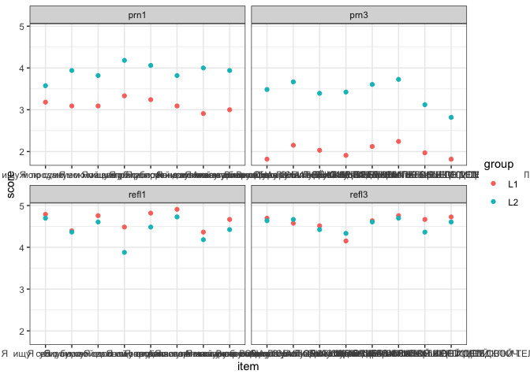

```r
ajt %>%
  filter(cond != "ungram") %>%  # убираем неграмматичное условие
  group_by(item, group, cond) %>% # группируем по условиям
  summarise(score = mean(value)) %>% # усредняем ответы информантов
  ggplot(aes(item, score, color = group)) +
  geom_point() +
  facet_wrap(~cond, scales = "free_x") +
  theme_bw()
```

Боже, как плохо. Давайте что ли оси перевернем…

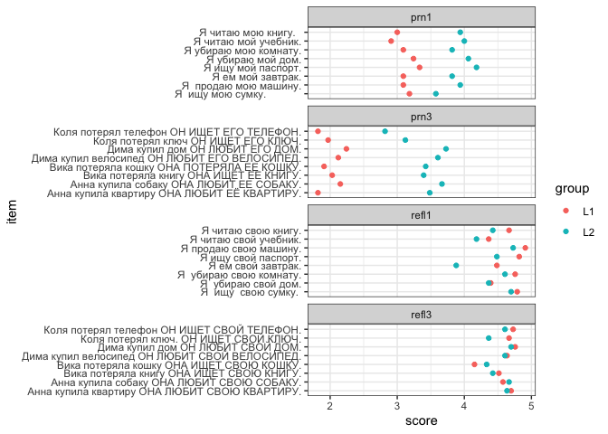

```r
ajt %>%
  filter(cond != "ungram") %>%  # убираем неграмматичное условие
  group_by(item, group, cond) %>% # группируем по условиям
  summarise(score = mean(value)) %>% # усредняем ответы информантов
  ggplot(aes(item, score, color = group)) +
  geom_point() +
  coord_flip() +
  facet_wrap(~ cond, ncol = 1, scales = "free_y") + # поменяли ось
  theme_bw()
```

А еще может быть другая проблема:

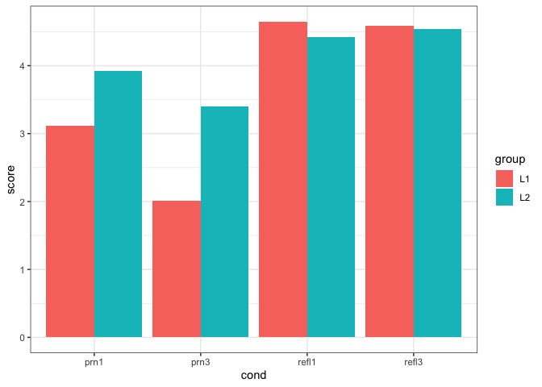

```r
ajt %>%
  filter(cond != "ungram") %>%  # убираем неграмматичное условие
  group_by(group, cond) %>% # группируем по условиям
  summarise(score = mean(value)) %>% # усредняем ответы информантов
  ggplot(aes(cond, score, fill = group)) +
  geom_col(position = position_dodge()) +
  theme_bw()
```

Вроде все приемлемо, однако ось `y` у нас начинается с 0, хотя минимальное значение по шкале оценки премлемости была 1. Надо поправить:

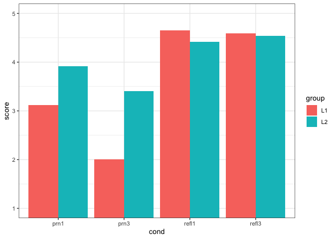

```r
ajt %>%
  filter(cond != "ungram") %>%  # убираем неграмматичное условие
  group_by(group, cond) %>% # группируем по условиям
  summarise(score = mean(value)) %>% # усредняем ответы информантов
  ggplot(aes(cond, score, fill = group)) +
  geom_col(position = position_dodge()) +
  coord_cartesian(ylim = c(1, 5)) +
  theme_bw()
```

# Встроенная статистическая обработка

Хорошо. На простеньком мы размялись — теперь надо сделать что-то посерьёзнее.

Часто бывает так, что мы хотим отобразить на графике не сырые данные, а какие-либо посчитанные статистики. Получается, сначала надо предобработать данные, получить необходимые значения, а затем на основе них строить график.

Но зачем? Если можно сразу в коде построения графика рассчитать все, что нам нужно! В `ggplot2` уже встроены инструменты простейшей статистический обработки!

Посмотрим, как влияют на [среднее] время реакции различные экспериментальные условия. Начнём с самого простого — количества стимулов на экране.

## Статы

Статы — это те самые встроенные инструменты статистической обработки. Они позволяют прямо в коде графика обсчитать данные и сразу визуализировать результаты.

> На самом деле, мы уже сталкивались со встроенными инструментами статистической обработки, ведь что делает `geom_smooth(method = "lm")`? Не что иное, как визуализирует линейную регрессию, построенную на выбранных данных!

Наиболее популярная функция из семейства `stat_*()` — это `stat_summary()`. С помощью неё можно удобно визуализировать средние.

Сразу зададим черно-белую тему на все последующие визуализации. Это делается так:

```r
theme_set(theme_bw())
```

Итак, мы хотим понять, как зависит среднее время реакции от количества стимулов. Нас будут интересовать пробы с одним целевым стимулом, поэтому отфильтруем все остальные, а также сразу расчертим базовый слой:

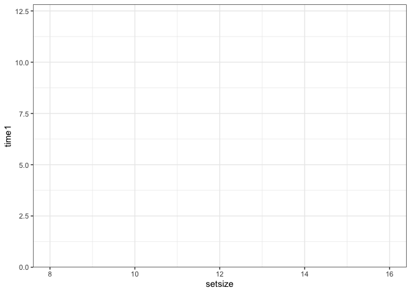

```r
share %>%
  filter(trialtype != "both") %>%
  ggplot(aes(setsize, time1))
```

Так, обратим внимание на следующий момент: на оси `x` обозначились числа 10 и 14, а таких сетсайзов в данных нет. Можем убедиться:

```r
unique(share$setsize)
```

```
## [1]  8 12 16
```

Это случилось потому, что переменная `setsize` записана в датасете как числовая, а для вычисления среднего времени реакции в каждом из условий будет нужна группировка наблюдений. По числовой переменной группировка невозможна, поэтому необходимо прописать, что данную переменную мы будем рассматривать как фактор:

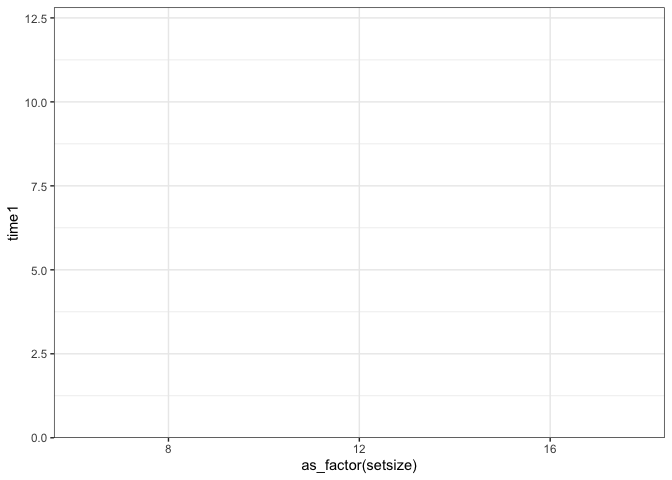

```r
share %>%
  filter(trialtype != "both") %>%
  ggplot(aes(as_factor(setsize), time1))
```

Во, теперь как надо.

Теперь добавляем средние. Как и полагается, на новый слой:

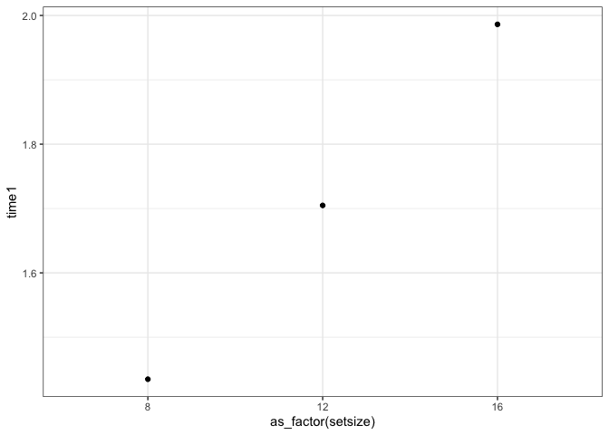

```r
share %>%
  filter(trialtype != "both") %>%
  ggplot(aes(as_factor(setsize), time1)) +
  stat_summary(fun = mean, geom = "point")
```

Разберемся, что тут написано. Первый аргумент (`fun`) принимает функцию, результат которой будет отложен по оси `y`. В нашем случае это среднее (`mean`). Она будет применена к переменой `time1`, причем наблюдения будут автоматически сгруппированы по интересующим нас группам. Второй аргумент — это уже знакомый нам геом, который отвечает за то, как «геометрически» будут отрисованы знаечния на графике. Наш выбор — точки. Как результат мы наблюдаем то, что хотели.

Однако как мы знаем из статистики, чтобы узнать, есть ли различия между условиями, нам недостаточно только средних значений — необходимы доверительные интервалы. Что ж, отобразим и их.

Добавим новый слой с помощью всё той же функции `stat_summary()`, но на этот раз она будет выглядеть немного по-другому:

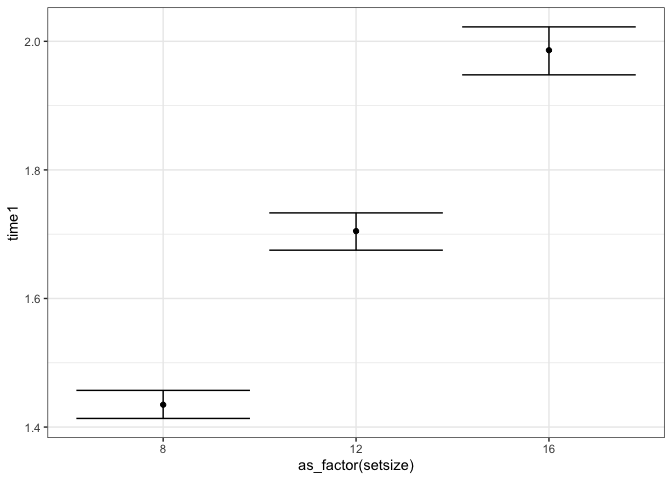

```r
share %>%
  filter(trialtype != "both") %>%
  ggplot(aes(as_factor(setsize), time1)) +
  stat_summary(fun = mean, geom = "point") +
  stat_summary(fun.data = mean_cl_boot, geom = "errorbar")
```

Как мы видим, немного изменился первый аргумент. Это связано с изменением геома. Для отображения доверительных интервалов нам нужен геом `errorbar`, который требует не одно значение, а два — верхнюю и нижнюю границу доверительного интервала. То есть `fun.data` принимает как аргумент мини-датафрейм — как раз в таком формате и возвращается результат функции `mean_cl_boot()`. Можно посмотреть на её работу отдельно:

```r
mean_cl_boot(share$time1)
```

```
##          y    ymin     ymax
## 1 1.599066 1.58551 1.611812
```

Собственно, вот он датафрейм из одной строки. Здесь три значения, но errorbar игронирует первое (оно и есть среднее значение) и использует только второе и третье, строя по ним «усы».

Собственно, график почти готов, однако добавим линии, которые будут соединять наши средние. Это допустимо в данной визуализации, так как мы отображаем повторные измерения и так более наглядно будет прослеживаться закономерность.

```
## geom_path: Each group consists of only one observation. Do you need to adjust
## the group aesthetic?
```

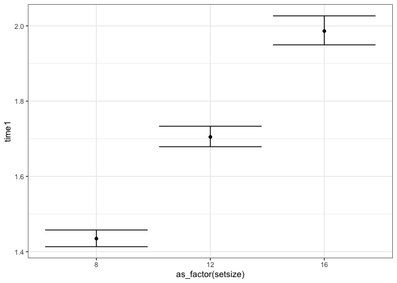

```r
share %>%
  filter(trialtype != "both") %>%
  ggplot(aes(as_factor(setsize), time1)) +
  stat_summary(fun = mean, geom = "point") +
  stat_summary(fun.data = mean_cl_boot, geom = "errorbar") +
  stat_summary(fun = mean, geom = "line")
```

Ага, вроде слой добавили, но ничего не изменилось. Еще и *warning* вылетел. Надо почитать!

`ggplot2` нам говорит, что каждая группа у нас содержит одно наблюдение — и он категорически прав, ведь у нас в каждой группе отображается только среднее значение. Из-за этого он не понимает, как ему нужно соединять точки. Надо ему подсказать, что с точки зрения соединения точек у нас всего одна группа, так как мы хотим, чтобы наши средние были последовательно соединены. Так и запишем (используя аргумент `group`):

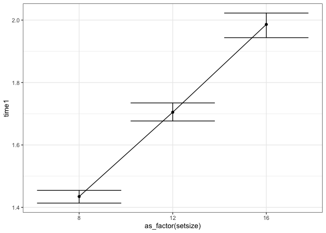

```r
share %>%
  filter(trialtype != "both") %>%
  ggplot(aes(as_factor(setsize), time1)) +
  stat_summary(fun = mean, geom = "point") +
  stat_summary(fun.data = mean_cl_boot, geom = "errorbar") +
  stat_summary(fun = mean, geom = "line",
               aes(group = 1))
```

Вот такая у нас классная линейная закономерность получилась! Ну, а чего мы ждали — зрительный поиск же…